# testRWS_api

Deltares

October 30, 2018

## Opvragen waterkwaliteitsdata door middel van RWS DDL API

Ik gebruik eigen R functies. Als package op github: wstolte/rwsapi. Dit package is nog in ontwikkeling.

```r
if(!require("rwsapi", character.only = TRUE)){
  devtools::install_github("wstolte/rwsapi")
  library("rwsapi", character.only = TRUE)
}
require(rwsapi)
```

## Aantal parameters

Opvragen metadata catalogus:

```r
metadata <- rwsapi::rws_metadata()
```

Dit zijn metadata van alle datasets in de DDL. Bijvoorbeeld, Nitraat, of Chlorophyll zit er in.

```r
metadata$content$AquoMetadataLijst$Parameter_Wat_Omschrijving[
  grep(x = metadata$content$AquoMetadataLijst$Parameter_Wat_Omschrijving, pattern = "nitraat", ignore.case = T)]
```

```
## [1] "Massafractie som nitraat en nitriet in Zwevende stof uitgedrukt in Stikstof / drooggewicht in mg/kg"
## [2] "(massa)Concentratie som nitraat en nitriet in Oppervlaktewater uitgedrukt in Stikstof in mg/l"
## [3] "(massa)Concentratie nitraat in Oppervlaktewater uitgedrukt in stikstof / opgeloste fractie in mg/l"
## [4] "(massa)Concentratie som nitraat en nitriet in Oppervlaktewater uitgedrukt in stikstof / opgeloste fractie in mg/l"
```

```r
metadata$content$AquoMetadataLijst$Parameter_Wat_Omschrijving[
  grep(x = metadata$content$AquoMetadataLijst$Parameter_Wat_Omschrijving, pattern = "chlorofy", ignore.case = T)]
```

```
## [1] "(massa)Concentratie chlorofyl-a in Oppervlaktewater ug/l"
```

```r
metadata$content$AquoMetadataLijst$Parameter_Wat_Omschrijving[
  grep(x = metadata$content$AquoMetadataLijst$Parameter_Wat_Omschrijving, pattern = "koolstof", ignore.case = T)]
```

```
## [1] "Massafractie koolstof organisch in Zwevende stof uitgedrukt in Koolstof / drooggewicht in %"
## [2] "Massafractie koolstof in Zwevende stof t.o.v. drooggewicht in %"
## [3] "(massa)Concentratie koolstof organisch in Oppervlaktewater uitgedrukt in koolstof / opgeloste fractie in mg/l"
## [4] "(massa)Concentratie koolstof organisch in Oppervlaktewater uitgedrukt in Koolstof particulair gebonden in mg/l"
## [5] "(massa)Concentratie koolstof organisch in Oppervlaktewater mg/l"
```

```r
which(metadata$content$AquoMetadataLijst$Parameter_Wat_Omschrijving == "(massa)Concentratie koolstof organisch in Oppervlaktewater mg/l") # = 375
```

```
## [1] 261
```

```r
metadata$content$AquoMetadataLijst$Parameter$Code[375]
```

```
## [1] "PBDE66"
```

Silikaat:

```r
metadata$content$AquoMetadataLijst$Parameter_Wat_Omschrijving[
  grep(x = metadata$content$AquoMetadataLijst$Parameter_Wat_Omschrijving, pattern = "sili", ignore.case = T)]
```

```
## [1] "(massa)Concentratie siliciumdioxide in Oppervlaktewater uitgedrukt in silicium / opgeloste fractie in mg/l"
```

Zit er nu ook in! Jippie!

Even kijken of extinctiecoefficient er al in zit:

```r
metadata$content$AquoMetadataLijst$Parameter_Wat_Omschrijving[
  grep(x = metadata$content$AquoMetadataLijst$Parameter_Wat_Omschrijving, pattern = "extinct", ignore.case = T)]
```

```
## character(0)
```

Nee, die helaas nog niet.

### Ophalen van data

R list structure wordt gebruikt als input in de functie hierboven.

```r
locatiecodes <- metadata$content$LocatieLijst$Code
grootheidcodes <- metadata$content$AquoMetadataLijst$Grootheid$Code
parametercodes <- metadata$content$AquoMetadataLijst$Parameter$Code
omschrijvingcodes <- metadata$content$AquoMetadataLijst$Parameter_Wat_Omschrijving

myparameter = "O2"
myquantity = "CONCTTE"

mylocation <- "TERSLG100"
locindex <- which(metadata$content$LocatieLijst$Code == mylocation)
x = metadata$content$LocatieLijst$X[locindex]
y = metadata$content$LocatieLijst$Y[locindex]

# create list for request
requestlist <- structure(list(
  AquoPlusWaarnemingMetadata = structure(list(
    AquoMetadata   = structure(list(
      Parameter    = structure(list(
        Code       = myparameter),
        .Names     = "Code"),
      Grootheid    = structure(list(
        Code       = myquantity),
        .Names     = "Code")),
      .Names       = c("Parameter", "Grootheid"))),
    .Names         = "AquoMetadata"),
  Locatie          = structure(list(
    X              = x,
    Y              = y,
    Code           = mylocation),
    .Names         = c("X","Y", "Code")),
  Periode          = structure(list(
    Begindatumtijd = "2013-11-27T09:00:00.000+01:00",
    Einddatumtijd  = "2018-01-28T09:01:00.000+01:00"),
    .Names         = c("Begindatumtijd", "Einddatumtijd"))),
  .Names           = c("AquoPlusWaarnemingMetadata", "Locatie", "Periode"))
```

Als JSON ziet de request er zo uit:

```r
print(toJSON(requestlist, auto_unbox = T, digits = NA))
```

{“AquoPlusWaarnemingMetadata”:{“AquoMetadata”:{“Parameter”:{“Code”:“O2”},“Grootheid”:{“Code”:“CONCTTE”}}},“Locatie”:{“X”:587556.434828345,“Y”:6000898.06976822,“Code”:“TERSLG100”},“Periode”:{“Begindatumtijd”:“2013-11-27T09:00:00.000+01:00”,“Einddatumtijd”:“2018-01-28T09:01:00.000+01:00”}}

### Uitvoeren request. De response is in dit geval een r list object

```r
response <- rwsapi::rws_observations(bodylist =requestlist)
```

Het omzetten van de response naar een dataframe, wat de gebruikelijke structuur is om bijvorbeel figuren te maken, bestaat uit het uitsplitsen van de verschillende onderdelen van het request

```r
  for(ii in seq(1:length(response$content$WaarnemingenLijst))) {
    temp.df = data.frame(
      locatie.code = response$content$WaarnemingenLijst[[ii]]$Locatie$Code,
      EPSG = response$content$WaarnemingenLijst[[ii]]$Locatie$Coordinatenstelsel,
      X = response$content$WaarnemingenLijst[[ii]]$Locatie$X,
      Y = response$content$WaarnemingenLijst[[ii]]$Locatie$Y,
      # locationname = ,
      tijdstip = lubridate::as_datetime(response$content$WaarnemingenLijst[[ii]]$MetingenLijst %>% map_chr(list(1), .default = NA)),
      referentievlak = response$content$WaarnemingenLijst[[ii]]$MetingenLijst %>% map_chr(list(3,3,1), .default = NA),
      bemonsteringshoogte = response$content$WaarnemingenLijst[[ii]]$MetingenLijst %>% map_chr(list(3,2,1), .default = NA),
      kwaliteitswaardecode = response$content$WaarnemingenLijst[[ii]]$MetingenLijst %>% map_chr(list(3,5,1), .default = NA),
      bemonsteringsapparaat = response$content$WaarnemingenLijst[[ii]]$AquoMetadata$BemonsteringsApparaat$Code,
      bemonsteringsSoort = response$content$WaarnemingenLijst[[ii]]$AquoMetadata$BemonsteringsSoort$Code,
      biotaxoncode = response$content$WaarnemingenLijst[[ii]]$AquoMetadata$BioTaxon$Code,
      biotaxoncompartimentcode = response$content$WaarnemingenLijst[[ii]]$AquoMetadata$BioTaxon_Compartiment$Code,
      compartimentcode = response$content$WaarnemingenLijst[[ii]]$AquoMetadata$Compartiment$Code,
      eenheidcode = response$content$WaarnemingenLijst[[ii]]$AquoMetadata$Eenheid$Code,
      grootheidcode = response$content$WaarnemingenLijst[[ii]]$AquoMetadata$Grootheid$Code,
      hoedanigheidcode = response$content$WaarnemingenLijst[[ii]]$AquoMetadata$Hoedanigheid$Code,
      meetapparaatcode = response$content$WaarnemingenLijst[[ii]]$AquoMetadata$MeetApparaat$Code,
      monsterbewerkingsmethodecode = response$content$WaarnemingenLijst[[ii]]$AquoMetadata$MonsterBewerkingsMethode$Code,
      orgaancode = response$content$WaarnemingenLijst[[ii]]$AquoMetadata$Orgaan$Code,
      parametercode = response$content$WaarnemingenLijst[[ii]]$AquoMetadata$Parameter$Code,
      plaatsbepalingsapparaatcode = response$content$WaarnemingenLijst[[ii]]$AquoMetadata$PlaatsBepalingsApparaat$Code,
      typeringcode = response$content$WaarnemingenLijst[[ii]]$AquoMetadata$Typering$Code,
      waardebepalingstechniekcode = response$content$WaarnemingenLijst[[ii]]$AquoMetadata$WaardeBepalingstechniek$Code,
      waardebepalingsmethodecode = response$content$WaarnemingenLijst[[ii]]$AquoMetadata$WaardeBepalingsmethode$Code,
      waardebewerkingsmethodecode = response$content$WaarnemingenLijst[[ii]]$AquoMetadata$WaardeBewerkingsmethode$Code,
      numeriekewaarde = response$content$WaarnemingenLijst[[ii]]$MetingenLijst %>% map_dbl(list("Meetwaarde", "Waarde_Numeriek"), .default = NA)
    )
    if(ii != 1){
      df = rbind(df, temp.df)
    }else df = temp.df
  }
df[df$numeriekewaarde>1e10,] <- NA
df <- df[!is.na(df$numeriekewaarde),]
knitr::kable(head(df), digits = 3, align = "r", format.args = list(font.size = 2))
```

| locatie.code | EPSG | X | Y | tijdstip | referentievlak | bemonsteringshoogte | kwaliteitswaardecode | bemonsteringsapparaat | bemonsteringsSoort | biotaxoncode | biotaxoncompartimentcode | compartimentcode | eenheidcode | grootheidcode | hoedanigheidcode | meetapparaatcode | monsterbewerkingsmethodecode | orgaancode | parametercode | plaatsbepalingsapparaatcode | typeringcode | waardebepalingstechniekcode | waardebepalingsmethodecode | waardebewerkingsmethodecode | numeriekewaarde |
| --- | --- | --- | --- | --- | --- | --- | --- | --- | --- | --- | --- | --- | --- | --- | --- | --- | --- | --- | --- | --- | --- | --- | --- | --- | --- |
| TERSLG100 | 25831 | 587556.4 | 6000898 | 2014-01-14 23:20:00 | WATSGL | -100 | 00 | 68 | 02 | NVT | NVT | OW | mg/l | CONCTTE | NVT | NVT | NVT | NVT | O2 | NVT | NVT | NVT | other:FW015 | NVT | 8.63 |
| TERSLG100 | 25831 | 587556.4 | 6000898 | 2014-02-11 07:29:00 | WATSGL | -100 | 00 | 68 | 02 | NVT | NVT | OW | mg/l | CONCTTE | NVT | NVT | NVT | NVT | O2 | NVT | NVT | NVT | other:FW015 | NVT | 8.98 |
| TERSLG100 | 25831 | 587556.4 | 6000898 | 2014-05-13 09:16:00 | WATSGL | -100 | 00 | 68 | 02 | NVT | NVT | OW | mg/l | CONCTTE | NVT | NVT | NVT | NVT | O2 | NVT | NVT | NVT | other:FW015 | NVT | 8.30 |
| TERSLG100 | 25831 | 587556.4 | 6000898 | 2014-06-24 17:44:00 | WATSGL | -100 | 00 | 68 | 02 | NVT | NVT | OW | mg/l | CONCTTE | NVT | NVT | NVT | NVT | O2 | NVT | NVT | NVT | other:FW015 | NVT | 8.22 |
| TERSLG100 | 25831 | 587556.4 | 6000898 | 2014-07-15 13:02:00 | WATSGL | -100 | 00 | 68 | 02 | NVT | NVT | OW | mg/l | CONCTTE | NVT | NVT | NVT | NVT | O2 | NVT | NVT | NVT | other:FW015 | NVT | 7.57 |
| TERSLG100 | 25831 | 587556.4 | 6000898 | 2015-05-12 11:03:00 | WATSGL | -100 | 00 | 68 | 02 | NVT | NVT | OW | mg/l | CONCTTE | NVT | NVT | NVT | NVT | O2 | NVT | NVT | NVT | other:FW015 | NVT | 9.09 |

## Tijdserie

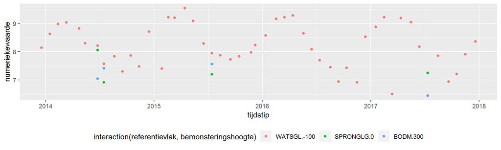

```r
ggplot(df, aes(tijdstip, numeriekewaarde)) + geom_point(aes(color = interaction(referentievlak, bemonsteringshoogte))) +
  theme(legend.position="bottom")
```

Dit ziet er goed uit. In Waterbase waren alleen oppervlaktewaarnemingen te zien, hier zijn ook diepere monsters meegenomen.